# Survey Data Analysis of Farmers in Jalgaon District

Manoj C. Patil

2025-04-02

## 1. Load Required Libraries

```r
library(tidyverse)    # Data manipulation and visualization
library(readxl)       # Read Excel files
library(DT)           # Interactive tables
library(dplyr)        # Data manipulation
library(ggplot2)      # Visualization
library(janitor)      # Clean column names
library(skimr)        # Summary statistics
library(knitr)        # To create formatted tables
```

## 2. Load Data

Set the file path and load all sheets from the Excel file.

```r
file_path <- "SurveyData.xlsx"  # Update with full path if needed
survey_main <- read_excel(file_path, sheet = 1) %>% clean_names()
family_members <- read_excel(file_path, sheet = "family_members") %>% clean_names()
earning_members <- read_excel(file_path, sheet = "earning_members") %>% clean_names()
family_responsibilities <- read_excel(file_path, sheet = "family_responsibilities") %>% clean_names()
health_details <- read_excel(file_path, sheet = "health_details") %>% clean_names()
```

## 3. Data Overview

### 3.1 Main Survey Data

```r
dim(survey_main)
```

```
## [1] 303 322
```

```r
skim(survey_main)  # Detailed summary
```

Data summary

| Name | survey_main |
| --- | --- |
| Number of rows | 303 |
| Number of columns | 322 |
| _______________________ |  |
| Column type frequency: |  |
| character | 185 |
| logical | 46 |
| numeric | 90 |
| POSIXct | 1 |
| ________________________ |  |
| Group variables | None |

**Variable type: character**

| skim_variable | n_missing | complete_rate | min | max | empty | n_unique | whitespace |
| --- | --- | --- | --- | --- | --- | --- | --- |
| farmer_id | 55 | 0.82 | 2 | 10 | 0 | 248 | 0 |
| farmers_name | 0 | 1.00 | 13 | 34 | 0 | 299 | 0 |
| village | 0 | 1.00 | 3 | 19 | 0 | 248 | 0 |
| taluka | 0 | 1.00 | 4 | 10 | 0 | 19 | 0 |
| gender | 0 | 1.00 | 4 | 6 | 0 | 2 | 0 |
| marital_status | 0 | 1.00 | 1 | 9 | 0 | 4 | 0 |
| education | 0 | 1.00 | 7 | 16 | 0 | 5 | 0 |
| religion | 0 | 1.00 | 4 | 13 | 0 | 12 | 0 |
| caste | 0 | 1.00 | 2 | 16 | 0 | 96 | 0 |
| subcaste | 0 | 1.00 | 1 | 18 | 0 | 84 | 0 |
| mother_tongue | 0 | 1.00 | 4 | 24 | 0 | 19 | 0 |
| family_type | 0 | 1.00 | 5 | 7 | 0 | 2 | 0 |
| head_of_family | 0 | 1.00 | 13 | 144 | 0 | 302 | 0 |
| relation_with_farmer | 0 | 1.00 | 2 | 28 | 0 | 16 | 0 |
| income_sources | 0 | 1.00 | 5 | 43 | 0 | 19 | 0 |
| otherincome | 302 | 0.00 | 16 | 16 | 0 | 1 | 0 |
| traditional_business | 0 | 1.00 | 2 | 32 | 0 | 21 | 0 |
| annual_income | 0 | 1.00 | 7 | 11 | 0 | 5 | 0 |
| bpl_status | 0 | 1.00 | 2 | 3 | 0 | 2 | 0 |
| ration_card | 0 | 1.00 | 4 | 6 | 0 | 4 | 0 |
| farmers_group | 62 | 0.80 | 2 | 3 | 0 | 2 | 0 |
| sh_group | 61 | 0.80 | 2 | 3 | 0 | 2 | 0 |
| land_type | 0 | 1.00 | 3 | 5 | 0 | 3 | 0 |
| irrigated_land | 0 | 1.00 | 1 | 14 | 0 | 66 | 0 |
| dry_land | 0 | 1.00 | 1 | 11 | 0 | 80 | 0 |
| total_land | 0 | 1.00 | 1 | 15 | 0 | 99 | 0 |
| soil_testing | 67 | 0.78 | 2 | 3 | 0 | 2 | 0 |
| water_sources | 0 | 1.00 | 4 | 19 | 0 | 15 | 0 |
| other_crops | 0 | 1.00 | 1 | 27 | 0 | 48 | 0 |
| x001 | 39 | 0.87 | 2 | 3 | 0 | 2 | 0 |

[output cut: 155 more lines]

**Variable type: logical**

| skim_variable | n_missing | complete_rate | mean | count |
| --- | --- | --- | --- | --- |
| other_improvements | 303 | 0 | NaN | : |
| text_ye0iz81 | 303 | 0 | NaN | : |
| x005 | 303 | 0 | NaN | : |
| life_insurance | 303 | 0 | NaN | : |
| agri_insurance | 303 | 0 | NaN | : |
| cropping_pattern | 303 | 0 | NaN | : |
| crops_kharif | 303 | 0 | NaN | : |
| crops_kharif_jowar | 303 | 0 | NaN | : |
| crops_kharif_bajra | 303 | 0 | NaN | : |
| crops_kharif_maize | 303 | 0 | NaN | : |
| crops_kharif_urad_moong | 303 | 0 | NaN | : |
| crops_kharif_soybean | 303 | 0 | NaN | : |
| crops_kharif_2 | 303 | 0 | NaN | : |
| crops_rabi | 303 | 0 | NaN | : |
| crops_rabi_wheat | 303 | 0 | NaN | : |
| crops_rabi_gram | 303 | 0 | NaN | : |
| crops_rabi_jowar_late | 303 | 0 | NaN | : |
| crops_rabi_2 | 303 | 0 | NaN | : |
| crops_summer | 303 | 0 | NaN | : |
| crops_summer_maize | 303 | 0 | NaN | : |
| crops_summer_sugarcane | 303 | 0 | NaN | : |
| crops_summer_groundnut | 303 | 0 | NaN | : |
| crops_summer_cucumber_melon | 303 | 0 | NaN | : |
| crops_summer_2 | 303 | 0 | NaN | : |
| crops_horticulture | 303 | 0 | NaN | : |
| crops_horticulture_banana | 303 | 0 | NaN | : |
| crops_horticulture_pomegranate | 303 | 0 | NaN | : |
| crops_horticulture_citrus | 303 | 0 | NaN | : |
| crops_horticulture_2 | 303 | 0 | NaN | : |
| other | 303 | 0 | NaN | : |
| text_lo1xd85 | 303 | 0 | NaN | : |
| health_conditions | 303 | 0 | NaN | : |
| health_conditions_heart_disease | 303 | 0 | NaN | : |
| health_conditions_diabetes | 303 | 0 | NaN | : |
| health_conditions_respiratory_disease | 303 | 0 | NaN | : |
| health_conditions_mental_stress | 303 | 0 | NaN | : |
| health_conditions_other_2 | 303 | 0 | NaN | : |
| x015 | 303 | 0 | NaN | : |
| other_farming_issues | 303 | 0 | NaN | : |
| job_card_2 | 303 | 0 | NaN | : |
| balasaheb_project | 303 | 0 | NaN | : |
| ahilyadevi_nursery | 303 | 0 | NaN | : |
| other_schemes | 303 | 0 | NaN | : |
| notes | 303 | 0 | NaN | : |
| submitted_by | 303 | 0 | NaN | : |
| tags | 303 | 0 | NaN | : |

**Variable type: numeric**

| skim_variable | n_missing | complete_rate | mean | sd | p0 | p25 | p50 | p75 | p100 | hist |
| --- | --- | --- | --- | --- | --- | --- | --- | --- | --- | --- |
| age | 0 | 1.00 | 44.56 | 12.59 | 5 | 35.00 | 44 | 53.00 | 76 | ▁▅▇▆▂ |
| total_family_members | 0 | 1.00 | 4.73 | 3.68 | 1 | 3.00 | 4 | 5.00 | 50 | ▇▁▁▁▁ |
| income_sources_agriculture | 0 | 1.00 | 0.93 | 0.26 | 0 | 1.00 | 1 | 1.00 | 1 | ▁▁▁▁▇ |
| income_sources_labour | 0 | 1.00 | 0.75 | 0.43 | 0 | 0.50 | 1 | 1.00 | 1 | ▃▁▁▁▇ |
| income_sources_job | 146 | 0.52 | 0.00 | 0.00 | 0 | 0.00 | 0 | 0.00 | 0 | ▁▁▇▁▁ |
| income_sources_business | 0 | 1.00 | 0.01 | 0.11 | 0 | 0.00 | 0 | 0.00 | 1 | ▇▁▁▁▁ |
| income_sources_privatejob | 0 | 1.00 | 0.06 | 0.23 | 0 | 0.00 | 0 | 0.00 | 1 | ▇▁▁▁▁ |
| income_sources_government_job | 0 | 1.00 | 0.01 | 0.11 | 0 | 0.00 | 0 | 0.00 | 1 | ▇▁▁▁▁ |
| income_sources_pension | 0 | 1.00 | 0.01 | 0.08 | 0 | 0.00 | 0 | 0.00 | 1 | ▇▁▁▁▁ |
| income_sources_other | 0 | 1.00 | 0.03 | 0.16 | 0 | 0.00 | 0 | 0.00 | 1 | ▇▁▁▁▁ |
| soil_tested_year | 295 | 0.03 | 6.00 | 4.75 | 2 | 2.75 | 4 | 8.00 | 15 | ▇▃▁▂▂ |
| water_sources_none | 0 | 1.00 | 0.51 | 0.50 | 0 | 0.00 | 1 | 1.00 | 1 | ▇▁▁▁▇ |
| water_sources_river | 0 | 1.00 | 0.02 | 0.13 | 0 | 0.00 | 0 | 0.00 | 1 | ▇▁▁▁▁ |
| water_sources_well | 0 | 1.00 | 0.36 | 0.48 | 0 | 0.00 | 0 | 1.00 | 1 | ▇▁▁▁▅ |
| water_sources_canal | 0 | 1.00 | 0.02 | 0.13 | 0 | 0.00 | 0 | 0.00 | 1 | ▇▁▁▁▁ |
| water_sources_borewell | 0 | 1.00 | 0.08 | 0.28 | 0 | 0.00 | 0 | 0.00 | 1 | ▇▁▁▁▁ |
| water_sources_farm_pond | 0 | 1.00 | 0.00 | 0.00 | 0 | 0.00 | 0 | 0.00 | 0 | ▁▁▇▁▁ |
| water_sources_reservoir | 0 | 1.00 | 0.00 | 0.06 | 0 | 0.00 | 0 | 0.00 | 1 | ▇▁▁▁▁ |
| water_sources_dam | 0 | 1.00 | 0.00 | 0.00 | 0 | 0.00 | 0 | 0.00 | 0 | ▁▁▇▁▁ |
| water_sources_neighbor_water | 0 | 1.00 | 0.05 | 0.21 | 0 | 0.00 | 0 | 0.00 | 1 | ▇▁▁▁▁ |
| cotton | 49 | 0.84 | 3.75 | 8.59 | 0 | 2.00 | 3 | 4.00 | 133 | ▇▁▁▁▁ |
| maize | 189 | 0.38 | 1.93 | 2.51 | 0 | 0.00 | 1 | 3.00 | 17 | ▇▁▁▁▁ |
| jowar | 237 | 0.22 | 0.48 | 1.04 | 0 | 0.00 | 0 | 0.75 | 5 | ▇▁▁▁▁ |
| bajra | 246 | 0.19 | 0.19 | 0.58 | 0 | 0.00 | 0 | 0.00 | 3 | ▇▁▁▁▁ |
| pulses | 246 | 0.19 | 0.33 | 0.85 | 0 | 0.00 | 0 | 0.00 | 3 | ▇▁▁▁▁ |
| soybean | 250 | 0.17 | 0.13 | 0.52 | 0 | 0.00 | 0 | 0.00 | 3 | ▇▁▁▁▁ |
| wheat | 226 | 0.25 | 1.74 | 3.18 | 0 | 0.00 | 0 | 2.00 | 20 | ▇▁▁▁▁ |
| gram | 222 | 0.27 | 1.54 | 2.39 | 0 | 0.00 | 1 | 2.00 | 17 | ▇▁▁▁▁ |
| sorghum | 250 | 0.17 | 0.42 | 0.93 | 0 | 0.00 | 0 | 0.00 | 4 | ▇▁▁▁▁ |
| maize2 | 221 | 0.27 | 2.16 | 2.76 | 0 | 0.00 | 1 | 4.00 | 15 | ▇▃▁▁▁ |

[output cut: 60 more lines]

**Variable type: POSIXct**

| skim_variable | n_missing | complete_rate | min | max | median | n_unique |
| --- | --- | --- | --- | --- | --- | --- |
| submission_time | 0 | 1 | 2025-02-27 16:29:31 | 2025-03-29 08:05:07 | 2025-03-07 14:26:48 | 303 |

```r
datatable(head(survey_main, 10), options = list(pageLength = 5))
```

|  | farmer_id | farmers_name | village | taluka | age | gender | marital_status | education | religion | caste | subcaste | mother_tongue | family_type | head_of_family | relation_with_farmer | total_family_members | income_sources | income_sources_agriculture | income_sources_labour | income_sources_job | income_sources_business | income_sources_privatejob | income_sources_government_job | income_sources_pension | income_sources_other | otherincome | traditional_business | annual_income | bpl_status | … |
| --- | --- | --- | --- | --- | --- | --- | --- | --- | --- | --- | --- | --- | --- | --- | --- | --- | --- | --- | --- | --- | --- | --- | --- | --- | --- | --- | --- | --- | --- | --- |
| 1 |  | नारायण रामलाल माळी | वडगाव बु | भडगाव | 37 | male | married | primary | हिंदू | फुलमाळी | ओबीसी | मराठी | nuclear | सोनाली नारायण माळी | पत्नी | 5 | agriculture labour | 1 | 1 |  | 0 | 0 | 0 | 0 | 0 |  | शेती | below_50k | no | … |
| 2 |  | शिवाजी नथ्थू महाजन | कजगाव | भडगाव | 44 | male | married | primary | हिंदू | माळी | OBC | मराठी | joint | सरला शिवाजी महाजन | पत्नी | 5 | agriculture labour | 1 | 1 |  | 0 | 0 | 0 | 0 | 0 |  | शेती | below_50k | no | … |
| 3 |  | दीपक आत्माराम पाटील | मळगाव | भडगाव | 48 | male | married | secondary | हिंदू | कुणबी | ओबीसी | मराठी , अहिराणी | nuclear | सुनंदा दीपक पाटील | पत्नी | 4 | agriculture | 1 | 0 |  | 0 | 0 | 0 | 0 | 0 |  | शेती | below_50k | no | … |
| 4 |  | नरेंद्र भिकन पाटील | कजगाव | भडगाव | 50 | male | married | primary | हिंदू | राजपूत | VJNT | मराठी | nuclear | छायाबाई नरेंद्र पाटील | पत्नी | 3 | agriculture labour | 1 | 1 |  | 0 | 0 | 0 | 0 | 0 |  | शेती | below_50k | yes | … |
| 5 |  | गजानन रामदास सोनवणे | केकतनिंभोरा | जामनेर | 25 | male | unmarried | secondary | हिन्दु | हिंदू कुणबी | ओ .बी .सी | मराठी | nuclear | वैभव रामदास सोनवणे | भाऊ | 4 | agriculture labour | 1 | 1 |  | 0 | 0 | 0 | 0 | 0 |  | शेती | below_50k | yes | … |
| 6 |  | भावेश भगवान वाघ / मराठे | गोंडखेल | जामनेर | 21 | male | unmarried | secondary | हिंदू | कुणबी | ओ.बी.सी. | मराठी | nuclear | भगवान तुकाराम मराठे | वडील | 3 | labour | 0 | 1 |  | 0 | 0 | 0 | 0 | 0 |  | शेतमजुरी | below_50k | yes | … |
| 7 |  | विलास भागवत चोपडे | गोंडखेल | जामनेर | 40 | male | married | illiterate | हिंदुं | कुणबी | ओ .बी सी . | मराठी | nuclear | वैभव विलास चोपडे | मुलगा | 5 | agriculture labour | 1 | 1 |  | 0 | 0 | 0 | 0 | 0 |  | शेतीकाम | below_50k | yes | … |
| 8 |  | अतुल देविदास महाजन | हिवरखेडा बु. | जामनेर | 36 | male | unmarried | secondary | हिंदू | रेवा गुज्जर | ओ .बी .सी | मराठी | nuclear | देविदास जगन्नाथ महाजन | वडील | 4 | labour | 0 | 1 |  | 0 | 0 | 0 | 0 | 0 |  | शेतीकाम | 50k_75k | no | … |
| 9 |  | छगन चत्रु राठोड | पोखरी | धरणगाव | 69 | male | married | illiterate | हिंदू | गोर बंजारा | बंजारा | बंजारा | joint | प्रकाश छगन राठोड | मोठा मुलगा | 15 | agriculture | 1 | 0 |  | 0 | 0 | 0 | 0 | 0 |  | शेती | below_50k | yes | … |
| 10 |  | देवा एकनाथ धनगर | पाळधी | धरणगाव | 43 | male | married | illiterate | हिंदू | धनगर NTC | Dhangar NTC | अहिराणी | nuclear | सुरेखा देवा धनगर | पत्नी | 3 | agriculture labour | 1 | 1 |  | 0 | 0 | 0 | 0 | 0 |  | शेती | below_50k | yes | … |

### 3.2 Family Members

```r
dim(family_members)
```

```
## [1] 1257   21
```

```r
skim(family_members)
```

Data summary

| Name | family_members |
| --- | --- |
| Number of rows | 1257 |
| Number of columns | 21 |
| _______________________ |  |
| Column type frequency: |  |
| character | 13 |
| logical | 3 |
| numeric | 4 |
| POSIXct | 1 |
| ________________________ |  |
| Group variables | None |

**Variable type: character**

| skim_variable | n_missing | complete_rate | min | max | empty | n_unique | whitespace |
| --- | --- | --- | --- | --- | --- | --- | --- |
| member_name | 0 | 1.00 | 4 | 147 | 0 | 1248 | 0 |
| relation | 0 | 1.00 | 1 | 23 | 0 | 59 | 0 |
| member_gender | 0 | 1.00 | 4 | 6 | 0 | 2 | 0 |
| member_marital_status | 0 | 1.00 | 1 | 9 | 0 | 4 | 0 |
| text_bq2fu40 | 454 | 0.64 | 1 | 21 | 0 | 84 | 0 |
| member_education | 0 | 1.00 | 7 | 16 | 0 | 6 | 0 |
| education_dropout_reason | 724 | 0.42 | 1 | 59 | 0 | 114 | 0 |
| x004 | 1088 | 0.13 | 1 | 19 | 0 | 24 | 0 |
| parent_table_name | 0 | 1.00 | 46 | 46 | 0 | 1 | 0 |
| submission_uuid | 0 | 1.00 | 36 | 36 | 0 | 303 | 0 |
| submission_validation_status | 1204 | 0.04 | 26 | 26 | 0 | 1 | 0 |
| submission_status | 0 | 1.00 | 17 | 17 | 0 | 1 | 0 |
| submission_version | 0 | 1.00 | 22 | 22 | 0 | 4 | 0 |

**Variable type: logical**

| skim_variable | n_missing | complete_rate | mean | count |
| --- | --- | --- | --- | --- |
| submission_notes | 1257 | 0 | NaN | : |
| submission_submitted_by | 1257 | 0 | NaN | : |
| submission_tags | 1257 | 0 | NaN | : |

**Variable type: numeric**

| skim_variable | n_missing | complete_rate | mean | sd | p0 | p25 | p50 | p75 | p100 | hist |
| --- | --- | --- | --- | --- | --- | --- | --- | --- | --- | --- |
| member_age | 0 | 1 | 30.63 | 19.31 | 1 | 16 | 28 | 41 | 109 | ▇▇▃▁▁ |
| index | 0 | 1 | 629.00 | 363.01 | 1 | 315 | 629 | 943 | 1257 | ▇▇▇▇▇ |
| parent_index | 0 | 1 | 158.29 | 86.15 | 1 | 85 | 160 | 233 | 303 | ▆▇▇▇▇ |
| submission_id | 0 | 1 | 450073925.06 | 2655812.22 | 446352748 | 447968561 | 449441009 | 451377825 | 457639385 | ▇▅▃▂▁ |

**Variable type: POSIXct**

| skim_variable | n_missing | complete_rate | min | max | median | n_unique |
| --- | --- | --- | --- | --- | --- | --- |
| submission_submission_time | 0 | 1 | 2025-02-27 16:29:31 | 2025-03-29 08:05:07 | 2025-03-08 06:58:49 | 303 |

```r
datatable(head(family_members, 10))
```

|  | member_name | relation | member_gender | member_age | member_marital_status | text_bq2fu40 | member_education | education_dropout_reason | x004 | index | parent_table_name | parent_index | submission_id | submission_uuid | submission_submission_time | submission_validation_status | submission_notes | submission_status | submission_submitted_by | submission_version | submission_tags |
| --- | --- | --- | --- | --- | --- | --- | --- | --- | --- | --- | --- | --- | --- | --- | --- | --- | --- | --- | --- | --- | --- |
| 1 | सोनाली नारायण माळी | पत्नी | female | 34 | married |  | higher_secondary | - | मजुरी | 1 | आत्महत्याग्रस्त शेतकऱ्यांच्या कुटुंब सर्वेक्षण | 1 | 446352748 | bd2afaf5-d102-48d8-9c7e-387119f12f90 | 2025-02-27T16:29:31Z | validation_status_approved |  | submitted_via_web |  | vzbsvqLSybZ6iREEDttont |  |
| 2 | रामलाल काशीराम माळी | वडील | male | 67 | married |  | primary | - | मजुरी | 2 | आत्महत्याग्रस्त शेतकऱ्यांच्या कुटुंब सर्वेक्षण | 1 | 446352748 | bd2afaf5-d102-48d8-9c7e-387119f12f90 | 2025-02-27T16:29:31Z | validation_status_approved |  | submitted_via_web |  | vzbsvqLSybZ6iREEDttont |  |
| 3 | उर्मिला रामलाल माळी | आई | female | 65 | married |  | illiterate | - | मजुरी | 3 | आत्महत्याग्रस्त शेतकऱ्यांच्या कुटुंब सर्वेक्षण | 1 | 446352748 | bd2afaf5-d102-48d8-9c7e-387119f12f90 | 2025-02-27T16:29:31Z | validation_status_approved |  | submitted_via_web |  | vzbsvqLSybZ6iREEDttont |  |
| 4 | अक्षय नारायण माळी | मुलगा | male | 17 | unmarried |  | higher_secondary | शिक्षण चालू | शिक्षण | 4 | आत्महत्याग्रस्त शेतकऱ्यांच्या कुटुंब सर्वेक्षण | 1 | 446352748 | bd2afaf5-d102-48d8-9c7e-387119f12f90 | 2025-02-27T16:29:31Z | validation_status_approved |  | submitted_via_web |  | vzbsvqLSybZ6iREEDttont |  |
| 5 | संभाजी नारायण माळी | मुलगा | male | 15 | unmarried |  | secondary | शिक्षण चालू | शिक्षण | 5 | आत्महत्याग्रस्त शेतकऱ्यांच्या कुटुंब सर्वेक्षण | 1 | 446352748 | bd2afaf5-d102-48d8-9c7e-387119f12f90 | 2025-02-27T16:29:31Z | validation_status_approved |  | submitted_via_web |  | vzbsvqLSybZ6iREEDttont |  |
| 6 | सखुबाई नथ्यू महाजन | आई | female | 65 | _ |  | illiterate |  | शेती | 6 | आत्महत्याग्रस्त शेतकऱ्यांच्या कुटुंब सर्वेक्षण | 2 | 446368488 | 054e4527-1fac-4e26-be30-07019e9f38b2 | 2025-02-27T17:10:11Z | validation_status_approved |  | submitted_via_web |  | vzbsvqLSybZ6iREEDttont |  |
| 7 | सरला शिवाजी महाजन | पत्नी | female | 40 | _ |  | secondary |  | शेती | 7 | आत्महत्याग्रस्त शेतकऱ्यांच्या कुटुंब सर्वेक्षण | 2 | 446368488 | 054e4527-1fac-4e26-be30-07019e9f38b2 | 2025-02-27T17:10:11Z | validation_status_approved |  | submitted_via_web |  | vzbsvqLSybZ6iREEDttont |  |
| 8 | वर्षा शिवाजी महाजन | मुलगी | female | 15 | unmarried |  | secondary |  | शिक्षण | 8 | आत्महत्याग्रस्त शेतकऱ्यांच्या कुटुंब सर्वेक्षण | 2 | 446368488 | 054e4527-1fac-4e26-be30-07019e9f38b2 | 2025-02-27T17:10:11Z | validation_status_approved |  | submitted_via_web |  | vzbsvqLSybZ6iREEDttont |  |
| 9 | हर्षदा शिवाजी महाजन | मुलगी | female | 21 | unmarried |  | graduate |  | शिक्षण | 9 | आत्महत्याग्रस्त शेतकऱ्यांच्या कुटुंब सर्वेक्षण | 2 | 446368488 | 054e4527-1fac-4e26-be30-07019e9f38b2 | 2025-02-27T17:10:11Z | validation_status_approved |  | submitted_via_web |  | vzbsvqLSybZ6iREEDttont |  |
| 10 | कुणाल शिवाजी महाजन | मुलगा | male | 15 | unmarried |  | secondary |  | शिक्षण | 10 | आत्महत्याग्रस्त शेतकऱ्यांच्या कुटुंब सर्वेक्षण | 2 | 446368488 | 054e4527-1fac-4e26-be30-07019e9f38b2 | 2025-02-27T17:10:11Z | validation_status_approved |  | submitted_via_web |  | vzbsvqLSybZ6iREEDttont |  |

### 3.3 Earning Members

```r
dim(earning_members)
```

```
## [1] 434  15
```

```r
skim(earning_members)
```

Data summary

| Name | earning_members |
| --- | --- |
| Number of rows | 434 |
| Number of columns | 15 |
| _______________________ |  |
| Column type frequency: |  |
| character | 7 |
| logical | 3 |
| numeric | 4 |
| POSIXct | 1 |
| ________________________ |  |
| Group variables | None |

**Variable type: character**

| skim_variable | n_missing | complete_rate | min | max | empty | n_unique | whitespace |
| --- | --- | --- | --- | --- | --- | --- | --- |
| earner_name | 0 | 1.00 | 13 | 52 | 0 | 432 | 0 |
| earning_source | 0 | 1.00 | 5 | 13 | 0 | 6 | 0 |
| parent_table_name | 0 | 1.00 | 46 | 46 | 0 | 1 | 0 |
| submission_uuid | 0 | 1.00 | 36 | 36 | 0 | 303 | 0 |
| submission_validation_status | 421 | 0.03 | 26 | 26 | 0 | 1 | 0 |
| submission_status | 0 | 1.00 | 17 | 17 | 0 | 1 | 0 |
| submission_version | 0 | 1.00 | 22 | 22 | 0 | 4 | 0 |

**Variable type: logical**

| skim_variable | n_missing | complete_rate | mean | count |
| --- | --- | --- | --- | --- |
| submission_notes | 434 | 0 | NaN | : |
| submission_submitted_by | 434 | 0 | NaN | : |
| submission_tags | 434 | 0 | NaN | : |

**Variable type: numeric**

| skim_variable | n_missing | complete_rate | mean | sd | p0 | p25 | p50 | p75 | p100 | hist |
| --- | --- | --- | --- | --- | --- | --- | --- | --- | --- | --- |
| monthly_income | 0 | 1 | 5522.60 | 5356.21 | 7 | 3.00000e+03 | 4000.0 | 6000.00 | 50000 | ▇▁▁▁▁ |
| index | 0 | 1 | 217.50 | 125.43 | 1 | 1.09250e+02 | 217.5 | 325.75 | 434 | ▇▇▇▇▇ |
| parent_index | 0 | 1 | 155.78 | 84.05 | 1 | 8.40000e+01 | 156.5 | 227.00 | 303 | ▆▇▇▇▇ |
| submission_id | 0 | 1 | 449958897.40 | 2540570.53 | 446352748 | 4.47964e+08 | 449429262.5 | 451353780.00 | 457639385 | ▇▅▃▂▁ |

**Variable type: POSIXct**

| skim_variable | n_missing | complete_rate | min | max | median | n_unique |
| --- | --- | --- | --- | --- | --- | --- |
| submission_submission_time | 0 | 1 | 2025-02-27 16:29:31 | 2025-03-29 08:05:07 | 2025-03-08 05:59:59 | 303 |

```r
datatable(head(earning_members, 10))
```

|  | earner_name | earning_source | monthly_income | index | parent_table_name | parent_index | submission_id | submission_uuid | submission_submission_time | submission_validation_status | submission_notes | submission_status | submission_submitted_by | submission_version | submission_tags |
| --- | --- | --- | --- | --- | --- | --- | --- | --- | --- | --- | --- | --- | --- | --- | --- |
| 1 | सोनाली नारायण माळी | agriculture | 4500 | 1 | आत्महत्याग्रस्त शेतकऱ्यांच्या कुटुंब सर्वेक्षण | 1 | 446352748 | bd2afaf5-d102-48d8-9c7e-387119f12f90 | 2025-02-27T16:29:31Z | validation_status_approved |  | submitted_via_web |  | vzbsvqLSybZ6iREEDttont |  |
| 2 | सरला शिवाजी महाजन | labour | 5000 | 2 | आत्महत्याग्रस्त शेतकऱ्यांच्या कुटुंब सर्वेक्षण | 2 | 446368488 | 054e4527-1fac-4e26-be30-07019e9f38b2 | 2025-02-27T17:10:11Z | validation_status_approved |  | submitted_via_web |  | vzbsvqLSybZ6iREEDttont |  |
| 3 | सुनंदा दीपक पाटील | labour | 4500 | 3 | आत्महत्याग्रस्त शेतकऱ्यांच्या कुटुंब सर्वेक्षण | 3 | 446370888 | 044343b2-6e61-43eb-9790-dec02384c468 | 2025-02-27T17:14:43Z | validation_status_approved |  | submitted_via_web |  | vzbsvqLSybZ6iREEDttont |  |
| 4 | छायाबाई नरेंद्र पाटील | agriculture | 3000 | 4 | आत्महत्याग्रस्त शेतकऱ्यांच्या कुटुंब सर्वेक्षण | 4 | 446408678 | 1171828a-85d4-4d0c-ba6c-ee3c70b8f059 | 2025-02-27T19:11:52Z | validation_status_approved |  | submitted_via_web |  | vzbsvqLSybZ6iREEDttont |  |
| 5 | वैभव रामदास सोनवणे | agriculture | 50000 | 5 | आत्महत्याग्रस्त शेतकऱ्यांच्या कुटुंब सर्वेक्षण | 5 | 446530719 | 796d8514-b53b-4d66-95bc-bf8c665223a5 | 2025-02-28T07:22:37Z | validation_status_approved |  | submitted_via_web |  | vzbsvqLSybZ6iREEDttont |  |
| 6 | भगवान तुकाराम मराठे | labour | 5000 | 6 | आत्महत्याग्रस्त शेतकऱ्यांच्या कुटुंब सर्वेक्षण | 6 | 446569566 | 9aa296e2-1f39-466a-b4b7-2e5bfa07216c | 2025-02-28T09:12:37Z | validation_status_approved |  | submitted_via_web |  | vzbsvqLSybZ6iREEDttont |  |
| 7 | वैभव विलास चोपडे | labour | 7 | 7 | आत्महत्याग्रस्त शेतकऱ्यांच्या कुटुंब सर्वेक्षण | 7 | 446589365 | c8948e1a-afd4-4ff4-949e-2f665ee43531 | 2025-02-28T10:02:12Z | validation_status_approved |  | submitted_via_web |  | vzbsvqLSybZ6iREEDttont |  |
| 8 | सचिन देविदास महाजन | labour | 10000 | 8 | आत्महत्याग्रस्त शेतकऱ्यांच्या कुटुंब सर्वेक्षण | 8 | 446605196 | ece59a3a-0b4a-494d-9bbe-3643394cfd87 | 2025-02-28T10:43:20Z | validation_status_approved |  | submitted_via_web |  | vzbsvqLSybZ6iREEDttont |  |
| 9 | प्रकाश छगन राठोड | agriculture | 8000 | 9 | आत्महत्याग्रस्त शेतकऱ्यांच्या कुटुंब सर्वेक्षण | 9 | 446776371 | e2a89e06-1ebb-4ce4-baf7-e13982d10151 | 2025-02-28T17:26:04Z | validation_status_approved |  | submitted_via_web |  | vzbsvqLSybZ6iREEDttont |  |
| 10 | Surekha dewa dhangar | labour | 5000 | 10 | आत्महत्याग्रस्त शेतकऱ्यांच्या कुटुंब सर्वेक्षण | 10 | 446877945 | 1ea6582a-6c7b-45e1-be86-09f22ecf7a2f | 2025-03-01T02:44:31Z | validation_status_approved |  | submitted_via_web |  | vzbsvqLSybZ6iREEDttont |  |

### 3.4 Family Responsibilities

```r
dim(family_responsibilities)
```

```
## [1] 300  19
```

```r
skim(family_responsibilities)
```

Data summary

| Name | family_responsibilities |
| --- | --- |
| Number of rows | 300 |
| Number of columns | 19 |
| _______________________ |  |
| Column type frequency: |  |
| character | 12 |
| logical | 3 |
| numeric | 3 |
| POSIXct | 1 |
| ________________________ |  |
| Group variables | None |

**Variable type: character**

| skim_variable | n_missing | complete_rate | min | max | empty | n_unique | whitespace |
| --- | --- | --- | --- | --- | --- | --- | --- |
| responsibility_type | 0 | 1.00 | 5 | 15 | 0 | 6 | 0 |
| responsibility_status | 0 | 1.00 | 2 | 3 | 0 | 2 | 0 |
| responsibility_status_010 | 0 | 1.00 | 2 | 3 | 0 | 2 | 0 |
| responsibility_status_009 | 0 | 1.00 | 2 | 3 | 0 | 2 | 0 |
| responsibility_status_008 | 0 | 1.00 | 2 | 3 | 0 | 2 | 0 |
| responsibility_status_007 | 0 | 1.00 | 2 | 3 | 0 | 2 | 0 |
| responsibility_status_001 | 0 | 1.00 | 2 | 3 | 0 | 2 | 0 |
| parent_table_name | 0 | 1.00 | 46 | 46 | 0 | 1 | 0 |
| submission_uuid | 0 | 1.00 | 36 | 36 | 0 | 296 | 0 |
| submission_validation_status | 288 | 0.04 | 26 | 26 | 0 | 1 | 0 |
| submission_status | 0 | 1.00 | 17 | 17 | 0 | 1 | 0 |
| submission_version | 0 | 1.00 | 22 | 22 | 0 | 4 | 0 |

**Variable type: logical**

| skim_variable | n_missing | complete_rate | mean | count |
| --- | --- | --- | --- | --- |
| submission_notes | 300 | 0 | NaN | : |
| submission_submitted_by | 300 | 0 | NaN | : |
| submission_tags | 300 | 0 | NaN | : |

**Variable type: numeric**

| skim_variable | n_missing | complete_rate | mean | sd | p0 | p25 | p50 | p75 | p100 | hist |
| --- | --- | --- | --- | --- | --- | --- | --- | --- | --- | --- |
| index | 0 | 1 | 1.5050e+02 | 86.75 | 1 | 75.75 | 150.5 | 225.25 | 300 | ▇▇▇▇▇ |
| parent_index | 0 | 1 | 1.5187e+02 | 86.71 | 1 | 77.75 | 149.5 | 226.25 | 303 | ▇▇▇▇▇ |
| submission_id | 0 | 1 | 4.4992e+08 | 2635603.08 | 446352748 | 447866443.75 | 449189736.5 | 451348642.50 | 457639385 | ▇▅▃▂▁ |

**Variable type: POSIXct**

| skim_variable | n_missing | complete_rate | min | max | median | n_unique |
| --- | --- | --- | --- | --- | --- | --- |
| submission_submission_time | 0 | 1 | 2025-02-27 16:29:31 | 2025-03-29 08:05:07 | 2025-03-07 12:09:45 | 296 |

```r
datatable(head(family_responsibilities, 10))
```

|  | responsibility_type | responsibility_status | responsibility_status_010 | responsibility_status_009 | responsibility_status_008 | responsibility_status_007 | responsibility_status_001 | index | parent_table_name | parent_index | submission_id | submission_uuid | submission_submission_time | submission_validation_status | submission_notes | submission_status | submission_submitted_by | submission_version | submission_tags |
| --- | --- | --- | --- | --- | --- | --- | --- | --- | --- | --- | --- | --- | --- | --- | --- | --- | --- | --- | --- |
| 1 | child_education | no | yes | no | no | yes | yes | 1 | आत्महत्याग्रस्त शेतकऱ्यांच्या कुटुंब सर्वेक्षण | 1 | 446352748 | bd2afaf5-d102-48d8-9c7e-387119f12f90 | 2025-02-27T16:29:31Z | validation_status_approved |  | submitted_via_web |  | vzbsvqLSybZ6iREEDttont |  |
| 2 | child_education | no | no | no | no | yes | no | 2 | आत्महत्याग्रस्त शेतकऱ्यांच्या कुटुंब सर्वेक्षण | 2 | 446368488 | 054e4527-1fac-4e26-be30-07019e9f38b2 | 2025-02-27T17:10:11Z | validation_status_approved |  | submitted_via_web |  | vzbsvqLSybZ6iREEDttont |  |
| 3 | boy_marriage | no | yes | no | yes | yes | yes | 3 | आत्महत्याग्रस्त शेतकऱ्यांच्या कुटुंब सर्वेक्षण | 3 | 446370888 | 044343b2-6e61-43eb-9790-dec02384c468 | 2025-02-27T17:14:43Z | validation_status_approved |  | submitted_via_web |  | vzbsvqLSybZ6iREEDttont |  |
| 4 | child_education | no | no | no | yes | yes | yes | 4 | आत्महत्याग्रस्त शेतकऱ्यांच्या कुटुंब सर्वेक्षण | 4 | 446408678 | 1171828a-85d4-4d0c-ba6c-ee3c70b8f059 | 2025-02-27T19:11:52Z | validation_status_approved |  | submitted_via_web |  | vzbsvqLSybZ6iREEDttont |  |
| 5 | child_education | no | no | no | no | no | no | 5 | आत्महत्याग्रस्त शेतकऱ्यांच्या कुटुंब सर्वेक्षण | 5 | 446530719 | 796d8514-b53b-4d66-95bc-bf8c665223a5 | 2025-02-28T07:22:37Z | validation_status_approved |  | submitted_via_web |  | vzbsvqLSybZ6iREEDttont |  |
| 6 | child_education | no | yes | no | no | yes | no | 6 | आत्महत्याग्रस्त शेतकऱ्यांच्या कुटुंब सर्वेक्षण | 6 | 446569566 | 9aa296e2-1f39-466a-b4b7-2e5bfa07216c | 2025-02-28T09:12:37Z | validation_status_approved |  | submitted_via_web |  | vzbsvqLSybZ6iREEDttont |  |
| 7 | child_education | yes | no | no | no | no | no | 7 | आत्महत्याग्रस्त शेतकऱ्यांच्या कुटुंब सर्वेक्षण | 7 | 446589365 | c8948e1a-afd4-4ff4-949e-2f665ee43531 | 2025-02-28T10:02:12Z | validation_status_approved |  | submitted_via_web |  | vzbsvqLSybZ6iREEDttont |  |
| 8 | child_education | no | yes | no | no | no | no | 8 | आत्महत्याग्रस्त शेतकऱ्यांच्या कुटुंब सर्वेक्षण | 9 | 446776371 | e2a89e06-1ebb-4ce4-baf7-e13982d10151 | 2025-02-28T17:26:04Z | validation_status_approved |  | submitted_via_web |  | vzbsvqLSybZ6iREEDttont |  |
| 9 | child_education | no | no | no | no | no | no | 9 | आत्महत्याग्रस्त शेतकऱ्यांच्या कुटुंब सर्वेक्षण | 10 | 446877945 | 1ea6582a-6c7b-45e1-be86-09f22ecf7a2f | 2025-03-01T02:44:31Z | validation_status_approved |  | submitted_via_web |  | vzbsvqLSybZ6iREEDttont |  |
| 10 | child_education | no | no | no | no | no | no | 10 | आत्महत्याग्रस्त शेतकऱ्यांच्या कुटुंब सर्वेक्षण | 11 | 446898337 | 18a45872-fd38-4eee-8244-af99c8eb70ae | 2025-03-01T05:40:27Z | validation_status_approved |  | submitted_via_web |  | vMHjNDDkH4nR2vEK33xMLo |  |

### 3.5 Health Details

```r
dim(health_details)
```

```
## [1] 213  19
```

```r
skim(health_details)
```

Data summary

| Name | health_details |
| --- | --- |
| Number of rows | 213 |
| Number of columns | 19 |
| _______________________ |  |
| Column type frequency: |  |
| character | 10 |
| logical | 3 |
| numeric | 5 |
| POSIXct | 1 |
| ________________________ |  |
| Group variables | None |

**Variable type: character**

| skim_variable | n_missing | complete_rate | min | max | empty | n_unique | whitespace |
| --- | --- | --- | --- | --- | --- | --- | --- |
| member_name_001 | 0 | 1.00 | 1 | 26 | 0 | 109 | 0 |
| disease_name | 0 | 1.00 | 1 | 87 | 0 | 82 | 0 |
| treatment_affordability | 0 | 1.00 | 10 | 12 | 0 | 2 | 0 |
| select_one_bz0nl29 | 49 | 0.77 | 2 | 3 | 0 | 2 | 0 |
| x016 | 175 | 0.18 | 2 | 3 | 0 | 2 | 0 |
| parent_table_name | 0 | 1.00 | 46 | 46 | 0 | 1 | 0 |
| submission_uuid | 0 | 1.00 | 36 | 36 | 0 | 200 | 0 |
| submission_validation_status | 203 | 0.05 | 26 | 26 | 0 | 1 | 0 |
| submission_status | 0 | 1.00 | 17 | 17 | 0 | 1 | 0 |
| submission_version | 0 | 1.00 | 22 | 22 | 0 | 4 | 0 |

**Variable type: logical**

| skim_variable | n_missing | complete_rate | mean | count |
| --- | --- | --- | --- | --- |
| submission_notes | 213 | 0 | NaN | : |
| submission_submitted_by | 213 | 0 | NaN | : |
| submission_tags | 213 | 0 | NaN | : |

**Variable type: numeric**

| skim_variable | n_missing | complete_rate | mean | sd | p0 | p25 | p50 | p75 | p100 | hist |
| --- | --- | --- | --- | --- | --- | --- | --- | --- | --- | --- |
| disease_duration | 0 | 1 | 12.28 | 138.43 | -1 | 0 | 0 | 5 | 2022 | ▇▁▁▁▁ |
| treatment_cost | 0 | 1 | 61165.56 | 684748.19 | -1 | 0 | 0 | 24000 | 10000000 | ▇▁▁▁▁ |
| index | 0 | 1 | 107.00 | 61.63 | 1 | 54 | 107 | 160 | 213 | ▇▇▇▇▇ |
| parent_index | 0 | 1 | 138.45 | 83.90 | 1 | 73 | 129 | 204 | 298 | ▇▇▇▆▆ |
| submission_id | 0 | 1 | 449506907.96 | 2373394.86 | 446352748 | 447679202 | 448462269 | 450629447 | 456896576 | ▇▃▂▁▁ |

**Variable type: POSIXct**

| skim_variable | n_missing | complete_rate | min | max | median | n_unique |
| --- | --- | --- | --- | --- | --- | --- |
| submission_submission_time | 0 | 1 | 2025-02-27 16:29:31 | 2025-03-27 08:53:52 | 2025-03-05 16:04:22 | 200 |

```r
datatable(head(health_details, 10))
```

|  | member_name_001 | disease_name | disease_duration | treatment_cost | treatment_affordability | select_one_bz0nl29 | x016 | index | parent_table_name | parent_index | submission_id | submission_uuid | submission_submission_time | submission_validation_status | submission_notes | submission_status | submission_submitted_by | submission_version | submission_tags |
| --- | --- | --- | --- | --- | --- | --- | --- | --- | --- | --- | --- | --- | --- | --- | --- | --- | --- | --- | --- |
| 1 | रामलाल काशीराम माळी | छातीत ब्लॉक | 2 | 75000 | unaffordable |  | Yes | 1 | आत्महत्याग्रस्त शेतकऱ्यांच्या कुटुंब सर्वेक्षण | 1 | 446352748 | bd2afaf5-d102-48d8-9c7e-387119f12f90 | 2025-02-27T16:29:31Z | validation_status_approved |  | submitted_via_web |  | vzbsvqLSybZ6iREEDttont |  |
| 2 | सरला शिवाजी महाराज | मधुमेह | 3 | 24000 | unaffordable |  | No | 2 | आत्महत्याग्रस्त शेतकऱ्यांच्या कुटुंब सर्वेक्षण | 2 | 446368488 | 054e4527-1fac-4e26-be30-07019e9f38b2 | 2025-02-27T17:10:11Z | validation_status_approved |  | submitted_via_web |  | vzbsvqLSybZ6iREEDttont |  |
| 3 | 0 | 0 | 0 | 0 | affordable |  | No | 3 | आत्महत्याग्रस्त शेतकऱ्यांच्या कुटुंब सर्वेक्षण | 3 | 446370888 | 044343b2-6e61-43eb-9790-dec02384c468 | 2025-02-27T17:14:43Z | validation_status_approved |  | submitted_via_web |  | vzbsvqLSybZ6iREEDttont |  |
| 4 | निरंक | निरंक | 0 | 0 | unaffordable |  | No | 4 | आत्महत्याग्रस्त शेतकऱ्यांच्या कुटुंब सर्वेक्षण | 4 | 446408678 | 1171828a-85d4-4d0c-ba6c-ee3c70b8f059 | 2025-02-27T19:11:52Z | validation_status_approved |  | submitted_via_web |  | vzbsvqLSybZ6iREEDttont |  |
| 5 | संगीता रामदास सोनवणे | दमा | 10 | 4000 | unaffordable |  | No | 5 | आत्महत्याग्रस्त शेतकऱ्यांच्या कुटुंब सर्वेक्षण | 5 | 446530719 | 796d8514-b53b-4d66-95bc-bf8c665223a5 | 2025-02-28T07:22:37Z | validation_status_approved |  | submitted_via_web |  | vzbsvqLSybZ6iREEDttont |  |
| 6 | Nil | Nil | 0 | 0 | unaffordable |  | No | 6 | आत्महत्याग्रस्त शेतकऱ्यांच्या कुटुंब सर्वेक्षण | 9 | 446776371 | e2a89e06-1ebb-4ce4-baf7-e13982d10151 | 2025-02-28T17:26:04Z | validation_status_approved |  | submitted_via_web |  | vzbsvqLSybZ6iREEDttont |  |
| 7 | Nil | Nil | 0 | 0 | unaffordable |  | Yes | 7 | आत्महत्याग्रस्त शेतकऱ्यांच्या कुटुंब सर्वेक्षण | 10 | 446877945 | 1ea6582a-6c7b-45e1-be86-09f22ecf7a2f | 2025-03-01T02:44:31Z | validation_status_approved |  | submitted_via_web |  | vzbsvqLSybZ6iREEDttont |  |
| 8 | नाही | नाही | 0 | 0 | unaffordable |  | No | 8 | आत्महत्याग्रस्त शेतकऱ्यांच्या कुटुंब सर्वेक्षण | 11 | 446898337 | 18a45872-fd38-4eee-8244-af99c8eb70ae | 2025-03-01T05:40:27Z | validation_status_approved |  | submitted_via_web |  | vMHjNDDkH4nR2vEK33xMLo |  |
| 9 | No | No | 0 | 0 | unaffordable |  | No | 9 | आत्महत्याग्रस्त शेतकऱ्यांच्या कुटुंब सर्वेक्षण | 12 | 447006586 | e9c115bd-5c93-4dbc-9fd6-294467a8da5d | 2025-03-01T13:22:57Z | validation_status_approved |  | submitted_via_web |  | vzbsvqLSybZ6iREEDttont |  |
| 10 | नाही | नाही | 0 | 0 | unaffordable |  | Yes | 10 | आत्महत्याग्रस्त शेतकऱ्यांच्या कुटुंब सर्वेक्षण | 13 | 447038617 | aa5eaa00-9723-4d80-a290-c13fa492cda2 | 2025-03-01T15:00:46Z | validation_status_approved |  | submitted_via_web |  | vzbsvqLSybZ6iREEDttont |  |

## 4. Data Cleaning

### Handle Missing Values and Standardize Data

```r
# Replace NA with appropriate values or remove if necessary
survey_main <- survey_main %>%
  mutate(age = as.numeric(age),
         annual_income = factor(annual_income, levels = c("below_50k", "50k_75k", "75k_1lakh", "1lakh_2lakh", "2lakh_5lakh", "above_5lakh")),
         gender = factor(gender, levels = c("male", "female", "other")))

# Check for missing values
colSums(is.na(survey_main))
```

```
##                                    farmer_id
##                                           55
##                                 farmers_name
##                                            0
##                                      village
##                                            0
##                                       taluka
##                                            0
##                                          age
##                                            0
##                                       gender
##                                            0
##                               marital_status
##                                            0
##                                    education
##                                            0
##                                     religion
##                                            0
##                                        caste
##                                            0
##                                     subcaste
##                                            0
##                                mother_tongue
##                                            0
##                                  family_type
##                                            0
##                               head_of_family
##                                            0
##                         relation_with_farmer
##                                            0
##                         total_family_members
##                                            0
##                               income_sources
##                                            0
##                   income_sources_agriculture
##                                            0
##                        income_sources_labour
##                                            0
##                           income_sources_job
##                                          146
```

[output cut: 589 more lines]

```
##                                            0
##                            validation_status
##                                          290
##                                        notes
##                                          303
##                                       status
##                                            0
##                                 submitted_by
##                                          303
##                                      version
##                                            0
##                                         tags
##                                          303
##                                        index
##                                            0
```

## 5. Descriptive Statistics

### 5.1 Age Distribution

```r
summary(survey_main$age)
```

```
##    Min. 1st Qu.  Median    Mean 3rd Qu.    Max.
##    5.00   35.00   44.00   44.56   53.00   76.00
```

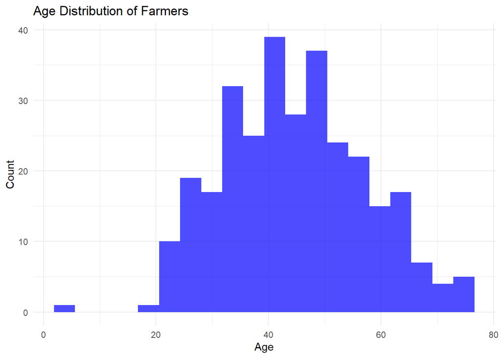

```r
survey_main %>%
  ggplot(aes(x = age)) +
  geom_histogram(bins = 20, fill = "blue", alpha = 0.7) +
  labs(title = "Age Distribution of Farmers", x = "Age", y = "Count") +
  theme_minimal()
```

### 5.2 Gender Distribution

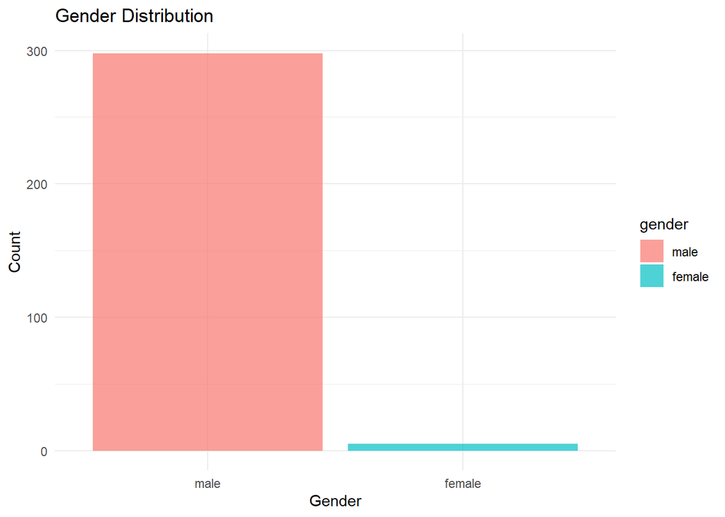

```r
survey_main %>%
  count(gender) %>%
  ggplot(aes(x = gender, y = n, fill = gender)) +
  geom_bar(stat = "identity", alpha = 0.7) +
  labs(title = "Gender Distribution", x = "Gender", y = "Count") +
  theme_minimal()
```

### 5.3 Education Levels

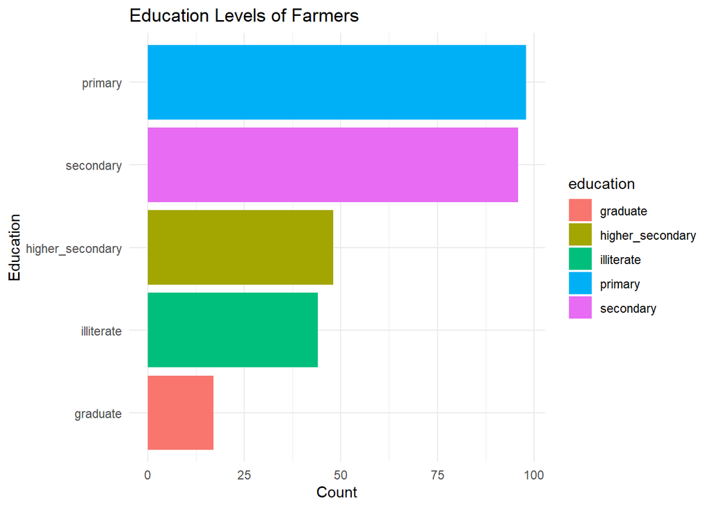

```r
survey_main %>%
  count(education) %>%
  ggplot(aes(x = reorder(education, n), y = n, fill = education)) +
  geom_bar(stat = "identity") +
  coord_flip() +
  labs(title = "Education Levels of Farmers", x = "Education", y = "Count") +
  theme_minimal()
```

### 5.4 Income Analysis

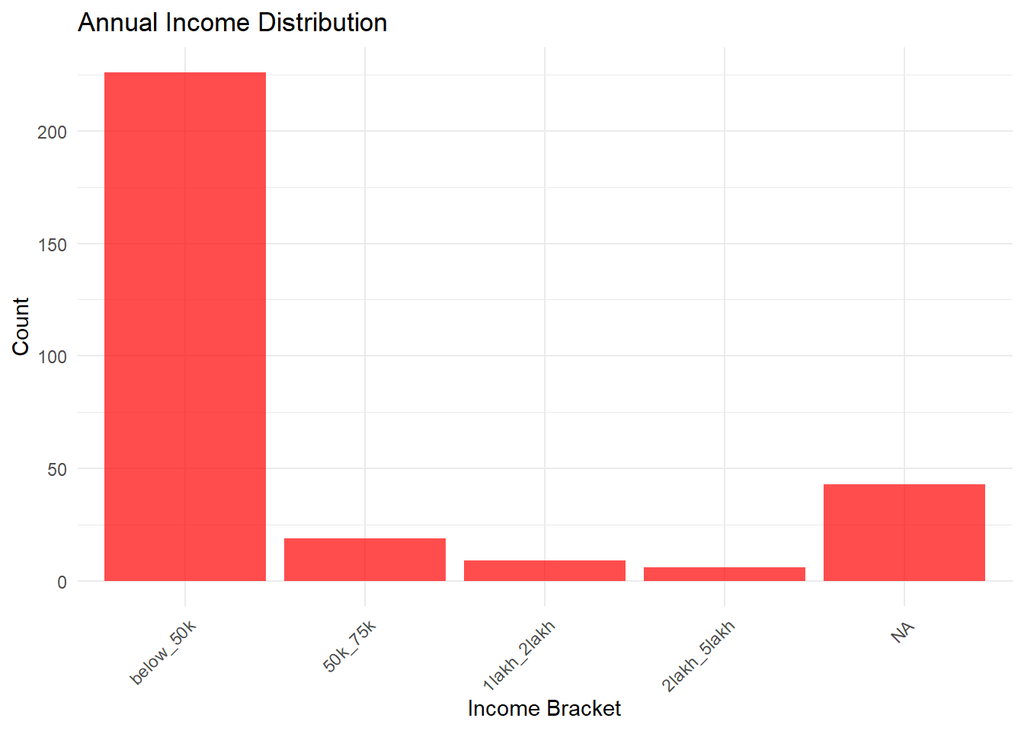

```r
survey_main %>%
  ggplot(aes(x = annual_income)) +
  geom_bar(fill = "red", alpha = 0.7) +
  labs(title = "Annual Income Distribution", x = "Income Bracket", y = "Count") +
  theme_minimal() +
  theme(axis.text.x = element_text(angle = 45, hjust = 1))
```

## 6. Land Ownership and Agriculture

### 6.1 Total Land Distribution

```r
unique(survey_main$total_land)
```

```
##  [1] "0"             "02"            "1"             "-"
##  [5] "3:1/2"         "२"             "००"            "४.०"
##  [9] "५  १/२"        "७"             "५"             "4"
## [13] "२५"            "३"             "०५"            "३.१०"
## [17] "00"            "3"             "3hectr"        "२.५ एकर"
## [21] "2hec"          "3एकर"          "1.5 एकर"       "4.5"
## [25] "4एकर"          "8"             "3.5"           "1.75 एकर"
## [29] "1.57"          "2.75"          "2"             "५ एकर"
## [33] "10.50 बिघे"     "2.5"           "2 बिघे"         "2.5 बिघे"
## [37] "5"             "6"             "10 बिघे"        "1.5"
## [41] "7 बिघे"         "3.2"           "10"            "7"
## [45] "03"            "1.9"           "1/2"           "01"
## [49] "17.7"          "2.30.00"       "1.85.00"       "4.5 बिघे"
## [53] "शेती नाही"      "1.63"          "s"             "3.26"
## [57] "3.22"          "8.15"          "२.४५"          "11.41"
## [61] "4.83"          "4.83 बिघे"      "८ .०५ बिगें"     "7.2"
## [65] "1 एकर"         "4.8"           "1.61 बिघे"      "3.2 बिघे"
## [69] "8 बि घे"        "3 बिधे"         "12"            "4 बि घे"
## [73] "5 बि घे"        "१"             "20"            "5 एकर"
## [77] "6.44"          "2.41"          "सव्वा दोन बिघे"  "08"
## [81] "1 बिघे"         "18"            "04"            "नाही"
## [85] "2 हेक्टर"        "दोन हेक्टर 22 R" "12 एकर"        "1.49R"
## [89] "4 एकर"         "54R"           "2 एकर"         "अर्धा एकर"
## [93] "7 एकर"         "8.5"           "2.81"          "1 हेक्टर"
## [97] "1.20 हेक्टर"     "0.6"           "1.7 हेक्टर"
```